# Homework_Week2

Meaghan Burke

September 7, 2019

### Week 2 Assignment

**HW - HA (6.2)**

2. The plastics data set consists of the monthly sales (in thousands) of product A for a plastics manufacturer for five years.
1. Plot the time series of sales of product A. Can you identify seasonal fluctuations and/or a trend-cycle?

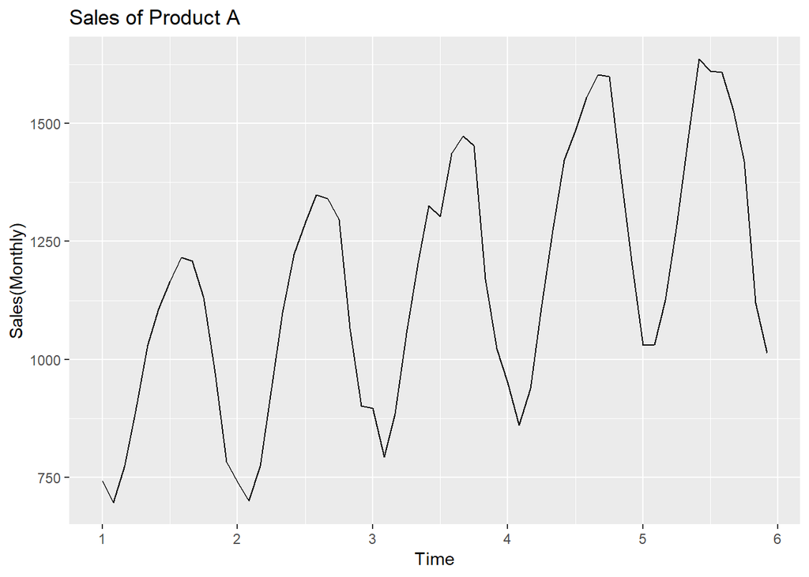

```r
autoplot(plastics) + ggtitle("Sales of Product A") + ylab("Sales(Monthly)")
```

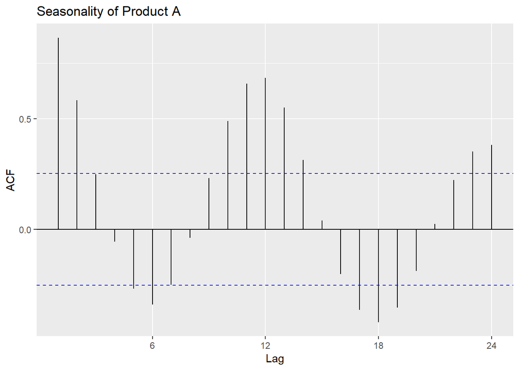

```r
ggAcf(plastics)+ ggtitle("Seasonality of Product A")
```

2. Use a classical multiplicative decomposition to calculate the trend-cycle and seasonal indices.

** The multiplicative decomposition shows a general upward trend from year 2 through year 5. After year 5, the trend appears to be decreasing. The decomposition graph also displays a seasonal shift (up/down) in one year increments.**

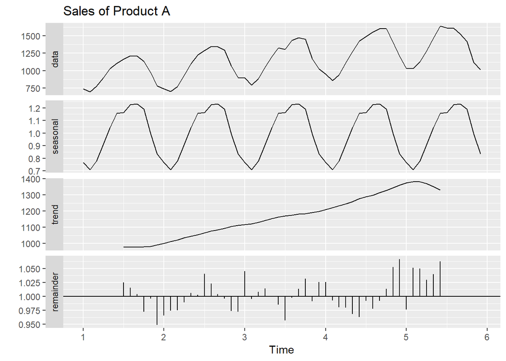

```r
plastics %>%
decompose(type="multiplicative") %>%
autoplot() +
ggtitle("Sales of Product A")
```

3. Do the results support the graphical interpretation from part a?

** Both part a and part b display a seasonal component of 1 year and a trend that is increasing over time. The decomposition does show a decline after year 5 because it relies on moving averages.** d. Compute and plot the seasonally adjusted data.

**The “Adjusted Seasonal” plot shows the sales with the seasonality removed, making the upward trend is more visable**

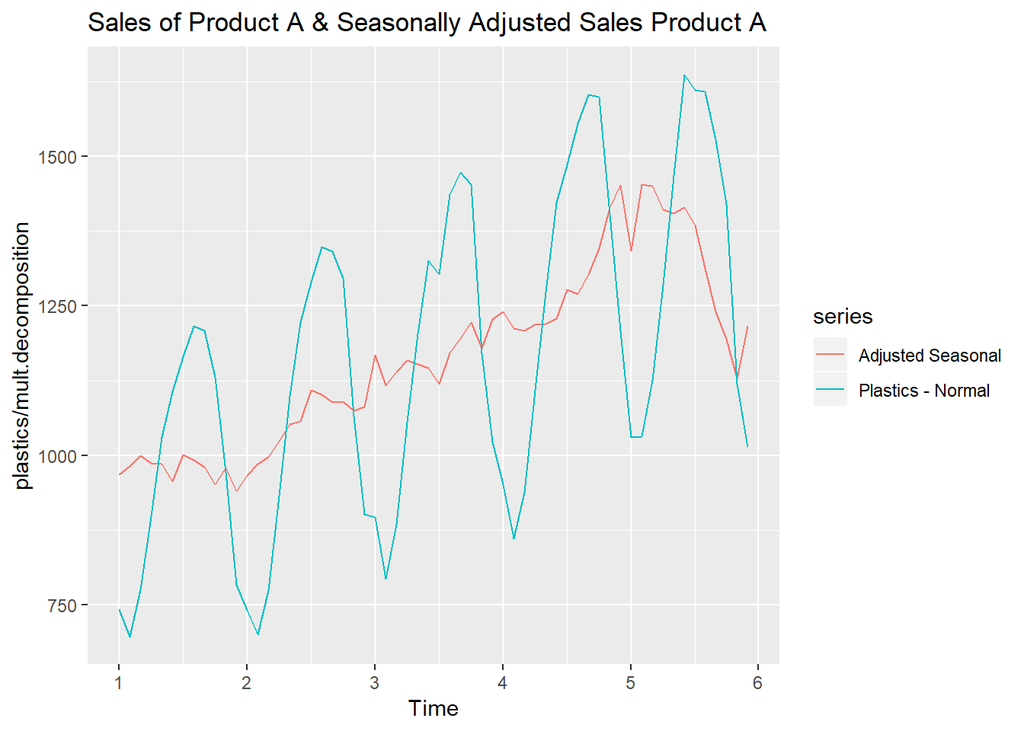

```r
mult.decomposition <- plastics %>%
  decompose(type="multiplicative") %>%
  seasonal


autoplot(plastics /mult.decomposition, series = "Adjusted Seasonal")+
  autolayer(plastics, series = "Plastics - Normal") +
  ggtitle("Sales of Product A & Seasonally Adjusted Sales Product A")
```

5. Change one observation to be an outlier (e.g., add 500 to one observation), and recompute the seasonally adjusted data. What is the effect of the outlier?

**After 500 was added to the 35th datapoint in “plastics.adj” dataset, a large spike occurred in the middle of the data series and the seasonally adjusted data series. This can be observed in the chart below.**

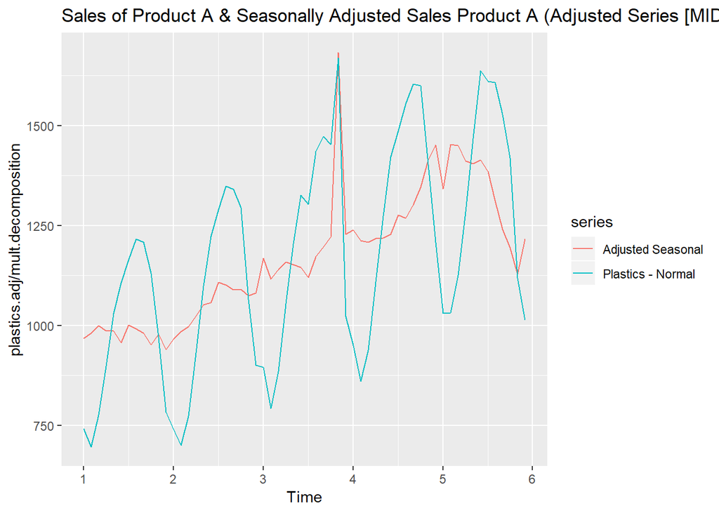

```r
plastics.adj <- plastics
plastics.adj[35] <- plastics.adj[35]+500


mult.decomposition.adj <- plastics.adj %>%
  decompose(type="multiplicative") %>%
  seasonal


autoplot(plastics.adj /mult.decomposition, series = "Adjusted Seasonal")+
  autolayer(plastics.adj, series = "Plastics - Normal") +
  ggtitle("Sales of Product A & Seasonally Adjusted Sales Product A (Adjusted Series [MIDDLE])")
```

6. Does it make any difference if the outlier is near the end rather than in the middle of the time series?

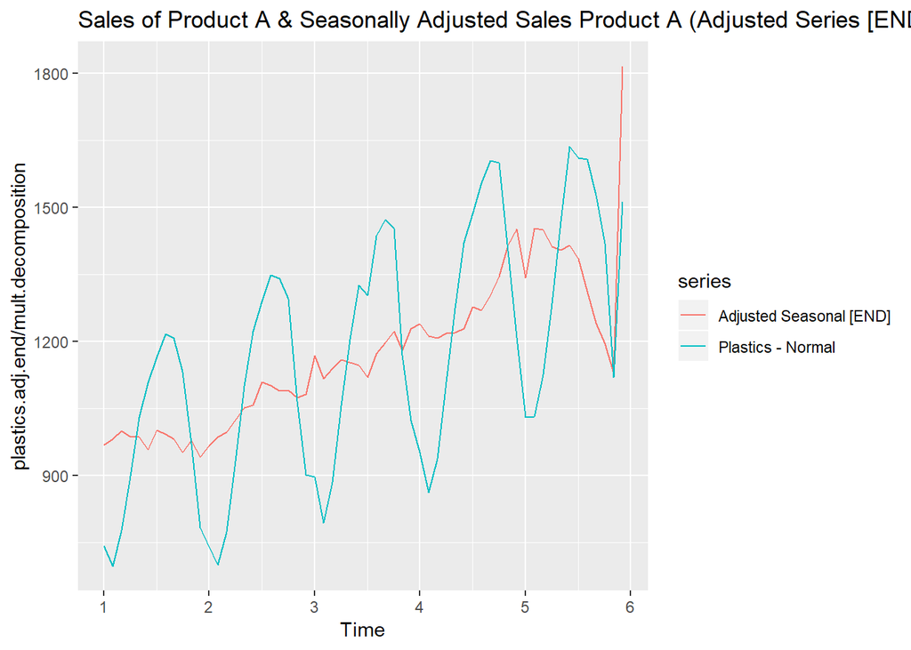

```r
end.series<- length(plastics)
plastics.adj.end <- plastics
plastics.adj.end[end.series] <- plastics.adj.end[end.series]+500


mult.decomposition.adj <- plastics.adj.end %>%
  decompose(type="multiplicative") %>%
  seasonal


autoplot(plastics.adj.end /mult.decomposition, series = "Adjusted Seasonal [END]")+
  autolayer(plastics.adj.end, series = "Plastics - Normal") +
  ggtitle("Sales of Product A & Seasonally Adjusted Sales Product A (Adjusted Series [END])")
```